# 7_MLPS_R_model_evaluation

Zhe Zhang (TA - Heinz CMU PhD)

1/28/2017

## Lecture 7: Model Evaluation

Key specific tasks we covered in this lecture:

- making a confusion matrix
- precision, recall, F-measure
- ROC curve graphic
- AUC
- precision-recall curve
- lift and profit curves

```r
library(tidyverse)
# Calculating a confusion matrix by hand
actual_outcomes = sample(c(0,1), 1000, r = T,
                         prob = c(2,1))
preds = c(runif(700, 0, 0.5), runif(300, 0, 1))

simple_classifer <- function(preds, cutoff) {
  if_else(preds >= cutoff, 1, 0)
}

TP = sum(simple_classifer(preds, 0.5) == 1 &
           actual_outcomes == 1)
FP = sum(simple_classifer(preds, 0.5) == 1 &
           actual_outcomes == 0)
FN = sum(simple_classifer(preds, 0.5) == 0 &
           actual_outcomes == 1)
TN = sum(simple_classifer(preds, 0.5) == 0 &
           actual_outcomes == 0)
sum(TP+FP+FN+TN)
```

```
## [1] 1000
```

```r
# see `caret` package for built-in confusion matrix
caret::confusionMatrix(data = factor(simple_classifer(preds, 0.5)),
                       reference = factor(actual_outcomes),
                       positive = "1")
```

```
## Confusion Matrix and Statistics
##
##           Reference
## Prediction   0   1
##          0 572 269
##          1  94  65
##
##                Accuracy : 0.637
##                  95% CI : (0.6063, 0.6669)
##     No Information Rate : 0.666
##     P-Value [Acc > NIR] : 0.9755
##
##                   Kappa : 0.0615
##  Mcnemar's Test P-Value : <2e-16
##
##             Sensitivity : 0.1946
##             Specificity : 0.8589
##          Pos Pred Value : 0.4088
##          Neg Pred Value : 0.6801
##              Prevalence : 0.3340
##          Detection Rate : 0.0650
##    Detection Prevalence : 0.1590
##       Balanced Accuracy : 0.5267
##
##        'Positive' Class : 1
##
```

Use the above values to calculate `precision`, `recall`, and `F-measure`.

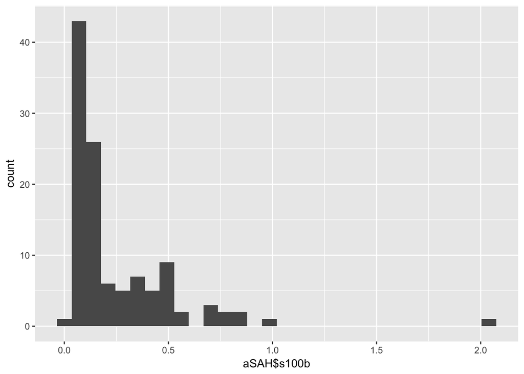

```r
# ROC and AUC
library(pROC)

# example with real dataset
data(aSAH)
qplot(aSAH$s100b)
```

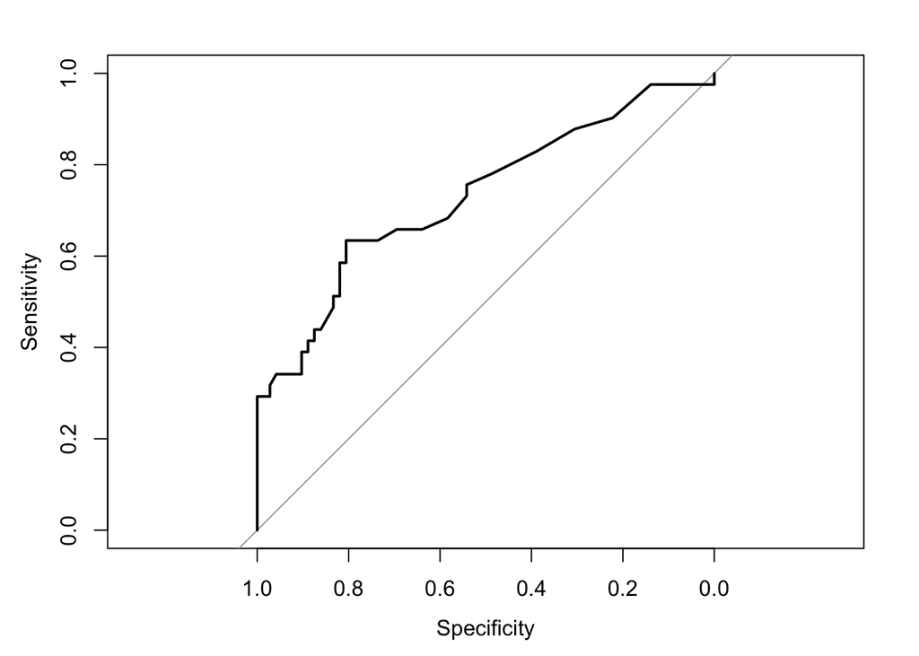

```
##
## Call:
## roc.default(response = aSAH$outcome, predictor = aSAH$s100b,     levels = c("Good", "Poor"))
##
## Data: aSAH$s100b in 72 controls (aSAH$outcome Good) < 41 cases (aSAH$outcome Poor).
## Area under the curve: 0.7314
```

```r
roc_obj_aSAH <- roc(aSAH$outcome, aSAH$s100b,
    levels=c("Good", "Poor"))
plot(roc_obj_aSAH)
```

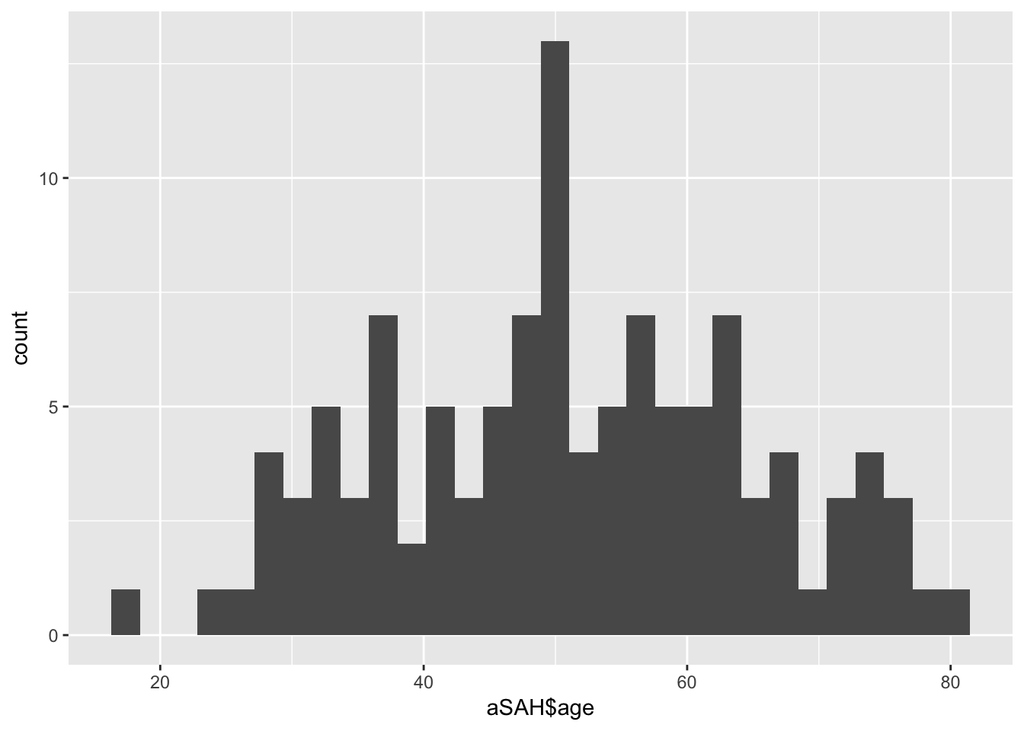

```r
# example using a bad predictor (can be any ordered values)
qplot(aSAH$age)
```

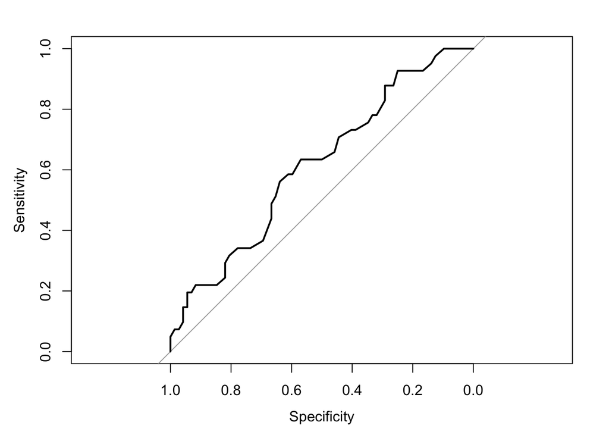

```
##
## Call:
## roc.default(response = aSAH$outcome, predictor = aSAH$age, levels = c("Good",     "Poor"))
##
## Data: aSAH$age in 72 controls (aSAH$outcome Good) < 41 cases (aSAH$outcome Poor).
## Area under the curve: 0.615
```

```r
roc_obj_aSAH <- roc(aSAH$outcome, aSAH$age,
    levels=c("Good", "Poor"))
plot(roc_obj_aSAH)
```

Precision/Recall curves: there doesn’t seem to be a way in `caret` to plot the PR curves. This recent package below seems good and well-documented (it conflicts with `pROC` package though).

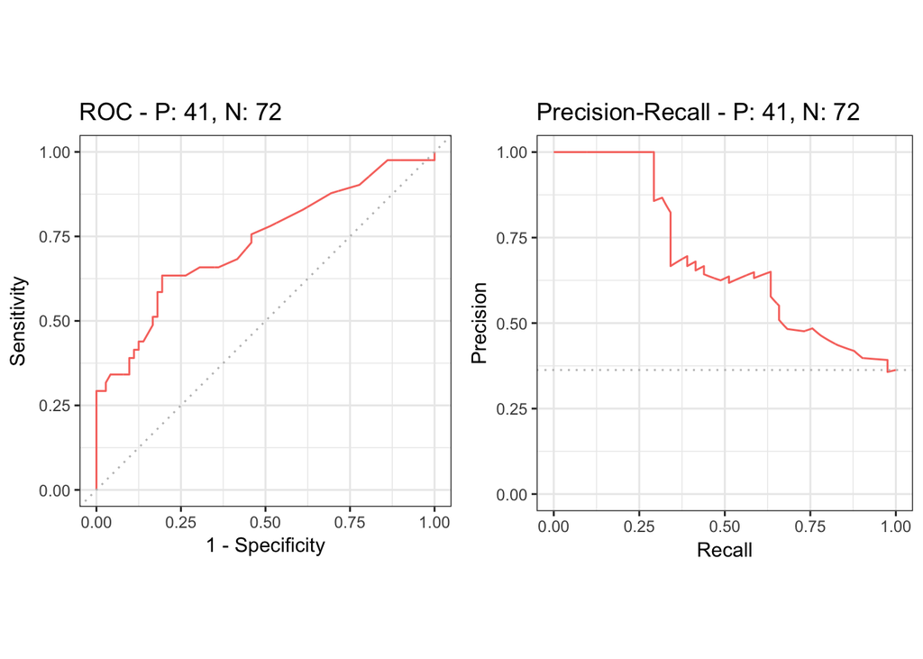

```r
library(precrec)
sscurves <- evalmod(scores = aSAH$s100b, labels = aSAH$outcome)
autoplot(sscurves)
```

Another version of a useful PR curve is to plot two line graphs, one measuring precision and the other measuring recall. On the x-axis, you can evaluate a grid between 0 and 1 (the range of your predictors) as the sample cutoff value. For each grid value, it will tell you the precision/recall for that cutoff. This is something that is missing on the above graphics, **what the cutoff values are**.

For Lift curves, see the following `caret` [tutorial section](https://topepo.github.io/caret/measuring-performance.html#lift-curves) showing the creation of lift curves that compare 3 different types of classifiers (FDA, LDA, and decision trees). First, they generate train/test data, pre-define some cross-validation splits, and then train the 3 models. Then, they make predictions from each of the 3 trained models on the test folds (*note, they put it all into one dataframe so that it can be easily plotted*). Then, they use the `caret` `lift` command to create the plots, where they show a roughly 2:1 lift to get 60% of the Positives.

To get the profit curves, use the Profit equation alongside the above calculated Lift results.

```r
# additional Lift example using earlier aSAH dataset

lift_obj <- caret::lift(outcome ~ s100b, data = aSAH, class = "Good")
print(lift_obj)
```

```
##
## Call:
## lift.formula(x = outcome ~ s100b, data = aSAH, class = "Good")
##
## Models: s100b
## Event: Good (63.7%)
```

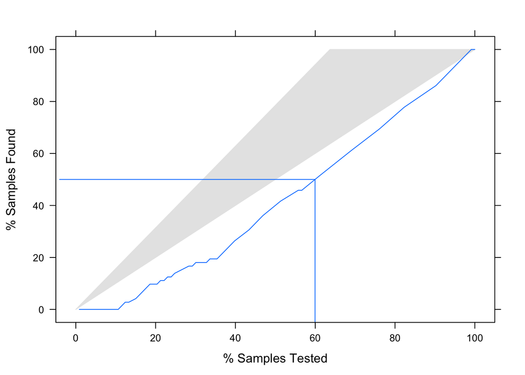

```r
plot(lift_obj, value = 50)
```